# Homework Week 7

Marwin Carmo

May 19, 2024

# Data

Data are from a study (March – April 2020) on 86 patients infected with COVID-19 who were treated in the emergency department (ED) of Lausanne University Hospital, Switzerland. The first google hit on https://datasetsearch.research.google.com/ landed me on their page (I only noted afterwards that data are from Switzerland - nothing personal): https://zenodo.org/record/3763421

These data include a number of variables as well as a an outcome 7 days into entering the study. Here, we will use `fu7_death` as the outcome variable – i.e., this variable records whether that study participant was alive or deceased by day 7.

The dataset is not really documented, but this is my guess of what these variables mean: Outcome at day 7

- `fu7_icu`: 1 = Intensive Care (lots of missings)
- `fu7_iot`: 1 = Intubated (lots of missings)
- `fu7_death`: 1 = Dead

You are free to play around with these variables.

The Other variables seem to have been recorded at the *entry* to the study 7 days earlier and most of them are self explanatory. We will use some of them as predictors.

### Read in data

Let’s read in the data and peak into it

```r
lus <- read.csv( file = "https://zenodo.org/record/3763421/files/Clinical_data.csv?download=1" )
head( lus, n =  5 )
```

|  | study_id | redcap_event_name | sex | age | height | weight | residence | tabac | oh | hbp | diabetes | heart_failure | heart_ischemia | stroke | neuro_disease | dementia | copd | asthma | neoplasia | neoplasia_type | liver_disease | renal_failure | hiv | inflammatory_chronic_disease | immunosuppressor | antibiotics_now | cough | cough_duration | sputum | … |
| --- | --- | --- | --- | --- | --- | --- | --- | --- | --- | --- | --- | --- | --- | --- | --- | --- | --- | --- | --- | --- | --- | --- | --- | --- | --- | --- | --- | --- | --- | --- |
| 1 | 129 | consultation_arm_1 | 1 | 87 | 1.65 | 49 | 1 | 0 | 0 | 0 | 1 | 0 | 0 | 0 | 1 | 0 | 0 | 0 | 0 | NA | 0 | 1 | 0 | 2 | 0 | NA | 1 | NA | 0 | … |
| 2 | 132 | consultation_arm_1 | 2 | 79 | NA | NA | 1 | 0 | 1 | 1 | 0 | 0 | 0 | 0 | 0 | 0 | 0 | 0 | 0 | NA | 0 | 0 | 0 | 2 | 0 | NA | 1 | NA | 0 | … |
| 3 | 136 | consultation_arm_1 | 2 | 85 | NA | NA | 1 | 0 | 0 | 0 | 1 | 0 | 0 | 0 | 0 | 0 | 0 | 0 | 0 | NA | 0 | 0 | 0 | 2 | 0 | 0 | 1 | 30 | 1 | … |
| 4 | 145 | consultation_arm_1 | 2 | 64 | 1.80 | 105 | 1 | 0 | 1 | 1 | 0 | 0 | 0 | 0 | 0 | 0 | 0 | 0 | 0 | NA | 0 | 0 | 0 | 2 | 0 | 1 | 1 | 7 | 0 | … |
| 5 | 147 | consultation_arm_1 | 2 | 68 | 1.89 | 100 | 1 | 0 | 0 | 1 | 0 | 0 | 0 | 0 | 0 | 0 | 0 | 0 | 0 | NA | 0 | 0 | 0 | 2 | 0 | NA | 1 | 10 | 1 | … |

### Subset Data

Select some variables of interest – note that some have lot’s of missing values. That is, I selected mostly those with few missings. So far, we haven’t talked about ways to deal with missing values, hence, I dropped all missing values with `na.omit()`.

I also recoded sex to by dummy-coded with 0 = male, and 1 = female

```r
lus2 <- na.omit( lus[ !is.na( lus$fu7_death) , c("sex", "age",  "hbp", "diabetes", "heart_ischemia",
                                                 "asthma", "cp_bp_systolic",  "cp_bp_diastolic",
                                                 "cp_saturation", "creatine", "leukocytes",
                                                 "status_pulm", "fu7_death")] )
## Recode sex, to 0 = males, 1 = females
lus2$sex <- lus2$sex - 1

## Center continuous variables at their grand mean:
head(lus2 )
```

|  | sex | age | hbp | diabetes | heart_ischemia | asthma | cp_bp_systolic | cp_bp_diastolic | cp_saturation | creatine | leukocytes | status_pulm | fu7_death |
| --- | --- | --- | --- | --- | --- | --- | --- | --- | --- | --- | --- | --- | --- |
| 1 | 0 | 87 | 0 | 1 | 0 | 0 | 126 | 74 | 96 | 115 | 4.4 | 1 | 0 |
| 2 | 1 | 79 | 1 | 0 | 0 | 0 | 145 | 85 | 96 | 108 | 12.1 | 0 | 0 |
| 4 | 1 | 64 | 1 | 0 | 0 | 0 | 131 | 81 | 95 | 146 | 6.2 | 1 | 0 |
| 5 | 1 | 68 | 1 | 0 | 0 | 0 | 144 | 78 | 97 | 76 | 6.5 | 1 | 0 |
| 6 | 1 | 29 | 0 | 0 | 0 | 1 | 114 | 80 | 100 | 112 | 7.3 | 0 | 0 |
| 7 | 1 | 55 | 1 | 0 | 0 | 0 | 135 | 82 | 97 | 91 | 10.8 | 0 | 0 |

```r
gmc <- scale(lus2[, c('age', 'cp_bp_systolic', 'cp_bp_diastolic', 'cp_saturation', 'creatine', 'leukocytes') ], center = TRUE, scale = FALSE)
colnames(gmc) <- paste0( colnames(gmc ), ".c")
lus2 <- data.frame(lus2, gmc)

## We're left with N = 61
nrow(lus2)
```

```
## [1] 61
```

# Question 1

We predict `fu7_death` as this variable seems to have relatively few missings by `sex`(0=male / 1=female), `age.c`, and `heart_ischemia` (0=not present / 1=present: Heart ischemia is a reduced blood flow to the heart, mostly due to calcification in the arteries)

Try thinking about a model that is capable of predicting 0/1 coded output, write it up formally. Also think about what priors would make sense – imagine that you’d be able to defend you prior choice in a review. Later we will fit this model: `fu7_death ~ sex + age.c + heart_ischemia`, you can use those variables or keep it more general, such as using $x_1$, $x_2$, etc. as placeholders for your specific variables.

### Answer:

Formal model:
$$\begin{align*}
y &\sim \text{Bernoulli}(p)\\
\text{logit}(p) &= \alpha + \beta_{sex} + \beta_{age_c} +
\beta_{ischemia}\\
\alpha &\sim \mathcal{N}(0, 10)\\
\beta_{age_c} &\sim \mathcal{N}(0, 10)\\
\beta_{ischemia}&\sim \mathcal{N}(0, 10)
\end{align*}$$

## Hints

### Hint:

If you need a hint, click on the next tab

### Hint/Solution: Formal Model

We are trying to predict the outcome `fu7_death` which is 0/1 coded. 0 is alive, 1 is dead. A logistic regression seems to be a natural choice where some of the predictors will increase or decrease the odds of dying due to COVID related complications.

As you may recall from PSC-204B, logistic regressions are general linear models based on a Bernoulli distribution with a logit link $\log\left( \frac{p}{1 - p} \right)$. In terms of defining this model, we can write a generic model (without direct reference to certain predictors) as:
$$\begin{align*}
\text{Likelihood:} \hspace{1cm} y &\sim Bern( \theta ) =
\begin{cases}
\theta \text{ if } y = 1\\
1 - \theta \text{ if } y = 0
\end{cases}
\text{ where } \theta \in \{0,1\} \\
& logit( \theta ) = log\left(\frac{\theta}{1-\theta}\right) =
\beta_0 + x_1\beta_1 + \ldots + x_p\beta_p
= \mathbf{X}\boldsymbol{\beta} \\
\text{ Prior for all elements in }\boldsymbol{\beta}\text{:}
\hspace{1cm} \boldsymbol{\beta} &\sim \mathcal{N}(\mathbf{0},
10\mathbf{I})
\end{align*}$$

In other words, our likelihood is defined as a Bernoulli function. Given the logit link that removes all bounds from our linear model, we can use relatively uninformed normal distributions for each of the $\beta$’s. Here, I chose a normal distribution with mean of zero and a standard deviation of 10 for each of the $\beta$’s

The next step is to write this model up in `brms`.

# Question 2

1. Now, take `sex`, `age`, and `heart_ischema` as predictors and `fu7_death` as the outcome and code it up in `brms`. Make sure the priors are reflecting the priors you defined in your formal model. *Interpret the model parameters.*

```r
names(lus2 )
```

```
##  [1] "sex"               "age"               "hbp"
##  [4] "diabetes"          "heart_ischemia"    "asthma"
##  [7] "cp_bp_systolic"    "cp_bp_diastolic"   "cp_saturation"
## [10] "creatine"          "leukocytes"        "status_pulm"
## [13] "fu7_death"         "age.c"             "cp_bp_systolic.c"
## [16] "cp_bp_diastolic.c" "cp_saturation.c"   "creatine.c"
## [19] "leukocytes.c"
```

```r
## brms model:

fit1 <- brms::brm(fu7_death ~ sex + age.c + heart_ischemia,
          family = bernoulli(link = "logit"),
          data = lus2,
          prior = prior(normal(0, 10), class = Intercept) +
            prior(normal(0, 10), class = "b", coef = "sex") +
            prior(normal(0, 10), class = "b", coef = "age.c") +
            prior(normal(0, 10), class = "b", coef = "heart_ischemia")
          )
```

```
## Trying to compile a simple C file
```

[output not shown]

```r
fit1
```

```
##  Family: bernoulli
##   Links: mu = logit
## Formula: fu7_death ~ sex + age.c + heart_ischemia
##    Data: lus2 (Number of observations: 61)
##   Draws: 4 chains, each with iter = 2000; warmup = 1000; thin = 1;
##          total post-warmup draws = 4000
##
## Regression Coefficients:
##                Estimate Est.Error l-95% CI u-95% CI Rhat Bulk_ESS Tail_ESS
## Intercept         -3.68      1.14    -6.31    -1.83 1.00     2314     1763
## sex               -0.82      1.20    -3.25     1.45 1.00     3430     2250
## age.c              0.06      0.05    -0.03     0.18 1.00     2425     1630
## heart_ischemia     3.04      1.22     0.74     5.57 1.00     2474     2213
##
## Draws were sampled using sampling(NUTS). For each parameter, Bulk_ESS
## and Tail_ESS are effective sample size measures, and Rhat is the potential
## scale reduction factor on split chains (at convergence, Rhat = 1).
```

The log-odds of death when all predictors are zero is -3.65. This indicates a very low probability of death in the baseline category. The log-odds of death decreases by 0.83 for females compared to males. We can also see that for each unit increase in centered age, the log-odds of death increases by 0.06. Finally, having heart ischemia increases the log-odds of death by 3.00. All parameters have an $\hat{R}$ of 1.00, indicating good convergence of the chains.

2. Fit another model that predicts `fu7_death`. For example, I chose `age.c`, `asthma`, `cp_saturation` as another set of predictors, but you can try different variables and/or variable combinations if you want. *Interpret the model parameters.*

```r
## brms model:

fit2 <- brms::brm(fu7_death ~ asthma + age.c + cp_saturation,
          family = bernoulli(link = "logit"),
          data = lus2,
          prior = prior(normal(0, 10), class = Intercept) +
            prior(normal(0, 10), class = "b", coef = "asthma") +
            prior(normal(0, 10), class = "b", coef = "age.c") +
            prior(normal(0, 10), class = "b", coef = "cp_saturation")
          )
```

```
## Trying to compile a simple C file
```

[output not shown]

```r
fit2
```

```
##  Family: bernoulli
##   Links: mu = logit
## Formula: fu7_death ~ asthma + age.c + cp_saturation
##    Data: lus2 (Number of observations: 61)
##   Draws: 4 chains, each with iter = 2000; warmup = 1000; thin = 1;
##          total post-warmup draws = 4000
##
## Regression Coefficients:
##               Estimate Est.Error l-95% CI u-95% CI Rhat Bulk_ESS Tail_ESS
## Intercept         7.49      5.86    -4.18    19.01 1.00     2819     2320
## asthma           -7.68      6.07   -21.79     0.62 1.00     1331     1390
## age.c             0.04      0.04    -0.03     0.12 1.00     2643     1739
## cp_saturation    -0.11      0.07    -0.24     0.02 1.00     2758     2177
##
## Draws were sampled using sampling(NUTS). For each parameter, Bulk_ESS
## and Tail_ESS are effective sample size measures, and Rhat is the potential
## scale reduction factor on split chains (at convergence, Rhat = 1).
```

The log-odds of death when all predictors are zero is 7.48. Having asthma decreases the log-odds of death by 7.77 compared to not having asthma. For each unit increase in centered age, the log-odds of death increases by 0.04. For each unit increase in capillary oxygen saturation, the log-odds of death decreases by 0.11. All parameters have an $\hat{R}$ of 1.00, indicating good convergence of the chains.

# Question 3: Check the model fit via *Posterior* PD

Find a way to check whether your models fit the data. Note that eg. `ppc_dens_overlay()` is for continuous variables - here we have a discrete outcome. You may want to take some inspiration from here: https://mc-stan.org/bayesplot/reference/PPC-overview.html

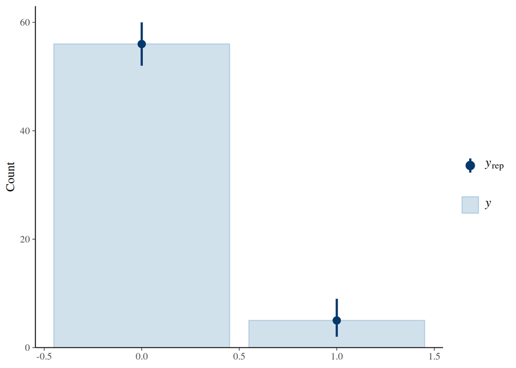

```r
## Posterior Predictive Checks

## Model 1
pp1 <- brms::posterior_predict(fit1)
ppc_bars(lus2$fu7_death, pp1)
```

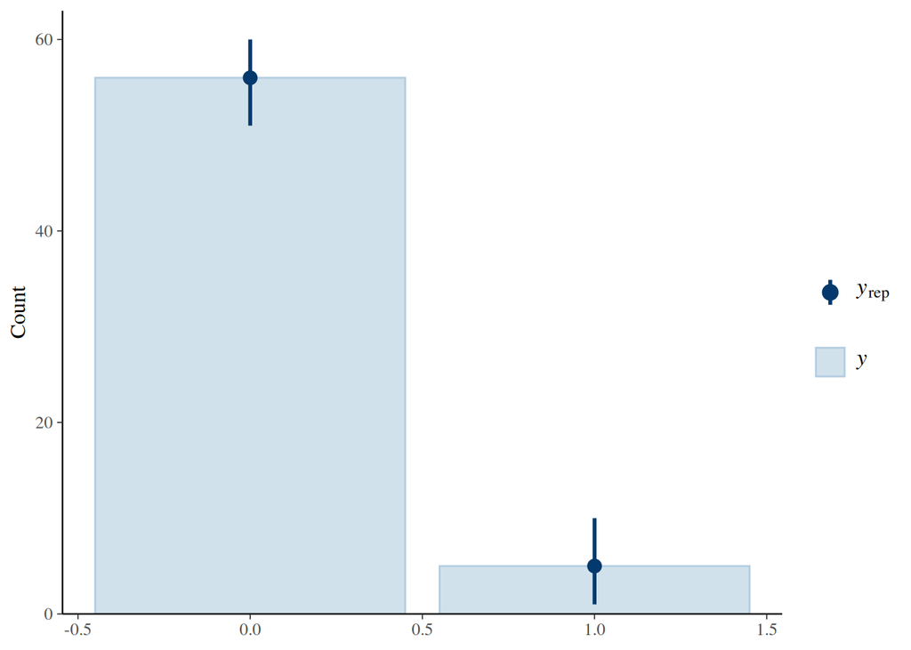

```r
## Model 2
pp2 <- brms::posterior_predict(fit2)
ppc_bars(lus2$fu7_death, pp2)
```

# Question 3: Compare models

Compare your models to each other:

1. Use the `loo` library and comment on the model you would prefer.

```r
## code
library( loo )
loo_fit1 <- loo(fit1)
loo_fit2 <- loo(fit2)

loo_compare(loo_fit1, loo_fit2)
```

```
##      elpd_diff se_diff
## fit2  0.0       0.0
## fit1 -1.1       4.5
```

2. Now, compare the two models via the Bayes Factor. Comment on what you find.

```r
## code
library(bridgesampling)
bf(bridge_sampler ( fit1 ) , bridge_sampler ( fit2 ))
```

[output not shown]

```
## Estimated Bayes factor in favor of bridge_sampler(fit1) over bridge_sampler(fit2): 15.04628
```